# Foodhub_Assignment1

## **FOODHUB ASSIGNMENT**

BY PRATEEK K SINGH

## **START**

```python
#Installing packages
#pip install seaborn -U -q
#pip install nltk -U -q
```

```python
# Importing packages for data exploration,number crunching ,visualization.
import pandas as pd
import numpy as np
import seaborn as sns
import matplotlib.pyplot as plt
import pandas as pd
import nltk as nl
```

```python
#Reading Data
df=pd.read_csv("foodhub_order.csv")
```

# Data Exploration

```python
df.head(5)
```

|  | order_id | customer_id | restaurant_name | cuisine_type | cost_of_the_order | day_of_the_week | rating | food_preparation_time | delivery_time |
| --- | --- | --- | --- | --- | --- | --- | --- | --- | --- |
| 0 | 1477147 | 337525 | Hangawi | Korean | 30.75 | Weekend | Not given | 25 | 20 |
| 1 | 1477685 | 358141 | Blue Ribbon Sushi Izakaya | Japanese | 12.08 | Weekend | Not given | 25 | 23 |
| 2 | 1477070 | 66393 | Cafe Habana | Mexican | 12.23 | Weekday | 5 | 23 | 28 |
| 3 | 1477334 | 106968 | Blue Ribbon Fried Chicken | American | 29.20 | Weekend | 3 | 25 | 15 |
| 4 | 1478249 | 76942 | Dirty Bird to Go | American | 11.59 | Weekday | 4 | 25 | 24 |

```python
df.describe(include='all').T
```

|  | count | unique | top | freq | mean | std | min | 25% | 50% | 75% | max |
| --- | --- | --- | --- | --- | --- | --- | --- | --- | --- | --- | --- |
| order_id | 1898.0 | NaN | NaN | NaN | 1477495.5 | 548.049724 | 1476547.0 | 1477021.25 | 1477495.5 | 1477969.75 | 1478444.0 |
| customer_id | 1898.0 | NaN | NaN | NaN | 171168.478398 | 113698.139743 | 1311.0 | 77787.75 | 128600.0 | 270525.0 | 405334.0 |
| restaurant_name | 1898 | 178 | Shake Shack | 219 | NaN | NaN | NaN | NaN | NaN | NaN | NaN |
| cuisine_type | 1898 | 14 | American | 584 | NaN | NaN | NaN | NaN | NaN | NaN | NaN |
| cost_of_the_order | 1898.0 | NaN | NaN | NaN | 16.498851 | 7.483812 | 4.47 | 12.08 | 14.14 | 22.2975 | 35.41 |
| day_of_the_week | 1898 | 2 | Weekend | 1351 | NaN | NaN | NaN | NaN | NaN | NaN | NaN |
| rating | 1898 | 4 | Not given | 736 | NaN | NaN | NaN | NaN | NaN | NaN | NaN |
| food_preparation_time | 1898.0 | NaN | NaN | NaN | 27.37197 | 4.632481 | 20.0 | 23.0 | 27.0 | 31.0 | 35.0 |
| delivery_time | 1898.0 | NaN | NaN | NaN | 24.161749 | 4.972637 | 15.0 | 20.0 | 25.0 | 28.0 | 33.0 |

```python
df.shape
```

```
(1898, 9)
```

```python
#Checking for null values
df.isnull().sum()
```

```
order_id                 0
customer_id              0
restaurant_name          0
cuisine_type             0
cost_of_the_order        0
day_of_the_week          0
rating                   0
food_preparation_time    0
delivery_time            0
dtype: int64
```

```python
#Checking for duplicates in the data
df.drop_duplicates(inplace=True)
df.head(5)
```

|  | order_id | customer_id | restaurant_name | cuisine_type | cost_of_the_order | day_of_the_week | rating | food_preparation_time | delivery_time |
| --- | --- | --- | --- | --- | --- | --- | --- | --- | --- |
| 0 | 1477147 | 337525 | Hangawi | Korean | 30.75 | Weekend | Not given | 25 | 20 |
| 1 | 1477685 | 358141 | Blue Ribbon Sushi Izakaya | Japanese | 12.08 | Weekend | Not given | 25 | 23 |
| 2 | 1477070 | 66393 | Cafe Habana | Mexican | 12.23 | Weekday | 5 | 23 | 28 |
| 3 | 1477334 | 106968 | Blue Ribbon Fried Chicken | American | 29.20 | Weekend | 3 | 25 | 15 |
| 4 | 1478249 | 76942 | Dirty Bird to Go | American | 11.59 | Weekday | 4 | 25 | 24 |

## **Quick Insights-1**

1. There is **no null value** in any column/row.
2. There is **no duplicate values** in the data.

```python
#Checking for data types
df.dtypes
```

```
order_id                   int64
customer_id                int64
restaurant_name           object
cuisine_type              object
cost_of_the_order        float64
day_of_the_week           object
rating                    object
food_preparation_time      int64
delivery_time              int64
dtype: object
```

```python
#Change "Not given" rating to "0" & column data type to integer for better visulaization and understanding.
df['rating']=df['rating'].replace('Not given',0)
df['rating']=df['rating'].astype(int)
```

```python
#Change restaurant_name,cuisine_type,day_of_the_week columns data type to "string".
df[['restaurant_name','cuisine_type','day_of_the_week']]=df[['restaurant_name','cuisine_type','day_of_the_week']].astype('string')
df['order_id']=df['order_id'].astype(str)
df['customer_id']=df['customer_id'].astype(str)
```

```python
df.head(5)
```

|  | order_id | customer_id | restaurant_name | cuisine_type | cost_of_the_order | day_of_the_week | rating | food_preparation_time | delivery_time |
| --- | --- | --- | --- | --- | --- | --- | --- | --- | --- |
| 0 | 1477147 | 337525 | Hangawi | Korean | 30.75 | Weekend | 0 | 25 | 20 |
| 1 | 1477685 | 358141 | Blue Ribbon Sushi Izakaya | Japanese | 12.08 | Weekend | 0 | 25 | 23 |
| 2 | 1477070 | 66393 | Cafe Habana | Mexican | 12.23 | Weekday | 5 | 23 | 28 |
| 3 | 1477334 | 106968 | Blue Ribbon Fried Chicken | American | 29.20 | Weekend | 3 | 25 | 15 |
| 4 | 1478249 | 76942 | Dirty Bird to Go | American | 11.59 | Weekday | 4 | 25 | 24 |

```python
df.dtypes
```

```
order_id                         object
customer_id                      object
restaurant_name          string[python]
cuisine_type             string[python]
cost_of_the_order               float64
day_of_the_week          string[python]
rating                            int64
food_preparation_time             int64
delivery_time                     int64
dtype: object
```

```python
# Count orders per customer
customer_order_count = (
    df.groupby('customer_id').agg(count=('customer_id', 'size'),restaurants=('restaurant_name', list)).reset_index()
)
# Keep only customers with more than 1 order and sort descending
repeat_customers = customer_order_count[customer_order_count['count'] > 1]\
                    .sort_values(by='count', ascending=False)\
                    .reset_index(drop=True)

repeat_customers
```

|  | customer_id | count | restaurants |
| --- | --- | --- | --- |
| 0 | 52832 | 13 | [Han Dynasty, ilili Restaurant, Dickson's Farm... |
| 1 | 47440 | 10 | [Blue Ribbon Fried Chicken, Blue Ribbon Fried ... |
| 2 | 83287 | 9 | [Five Guys Burgers and Fries, Blue Ribbon Sush... |
| 3 | 250494 | 8 | [Five Guys Burgers and Fries, The Meatball Sho... |
| 4 | 82041 | 7 | [Shake Shack, Osteria Morini, Parm, Parm, Shak... |
| ... | ... | ... | ... |
| 411 | 236739 | 2 | [Xi'an Famous Foods, Xi'an Famous Foods] |
| 412 | 240982 | 2 | [Rubirosa, Rubirosa] |
| 413 | 86731 | 2 | [Mission Cantina, Mission Cantina] |
| 414 | 87357 | 2 | [Shake Shack, Five Guys Burgers and Fries] |
| 415 | 87752 | 2 | [Shake Shack, Shake Shack] |

416 rows × 3 columns

```python
#Count order from restaurant
order_count = (
    df.groupby('order_id')
      .size()
      .reset_index(name='count')
).sort_values(by='count', ascending=False)\
                    .reset_index(drop=True)
order_count
```

|  | order_id | count |
| --- | --- | --- |
| 0 | 1476547 | 1 |
| 1 | 1476548 | 1 |
| 2 | 1476549 | 1 |
| 3 | 1476550 | 1 |
| 4 | 1476551 | 1 |
| ... | ... | ... |
| 1893 | 1478440 | 1 |
| 1894 | 1478441 | 1 |
| 1895 | 1478442 | 1 |
| 1896 | 1478443 | 1 |
| 1897 | 1478444 | 1 |

1898 rows × 2 columns

## **Quick Insights – 2**

1. There are **416 repeat customers**, with a maximum of **13 orders** placed by a single customer.

```python
# Unique Cuisines
df['cuisine_type'].nunique()
```

```
14
```

```python
#Unique Restaurants
df['restaurant_name'].nunique()
```

```
178
```

# Univariate Analysis(Numerical)

## Cost of Order

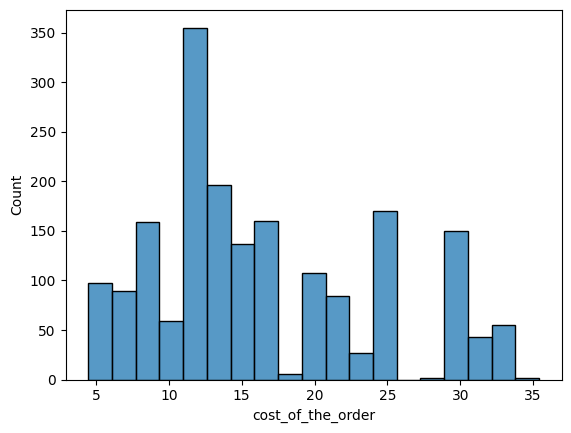

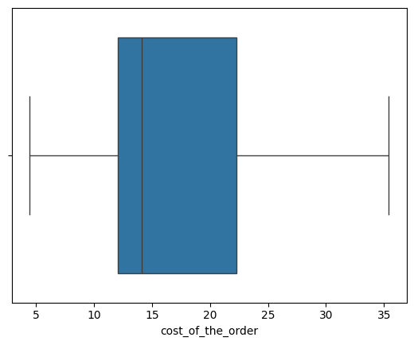

```python
sns.histplot(data=df,x='cost_of_the_order')
plt.show()
sns.boxplot(data=df,x='cost_of_the_order')
plt.show()
```

## Rating

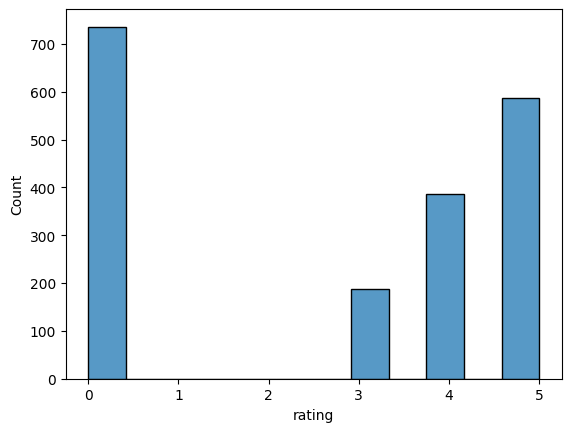

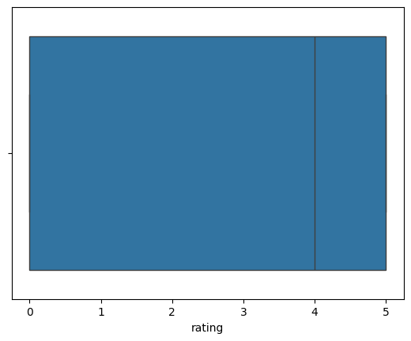

```python
sns.histplot(data=df,x='rating')
plt.show()
sns.boxplot(data=df,x='rating')
plt.show()
```

## Food Preparation Time

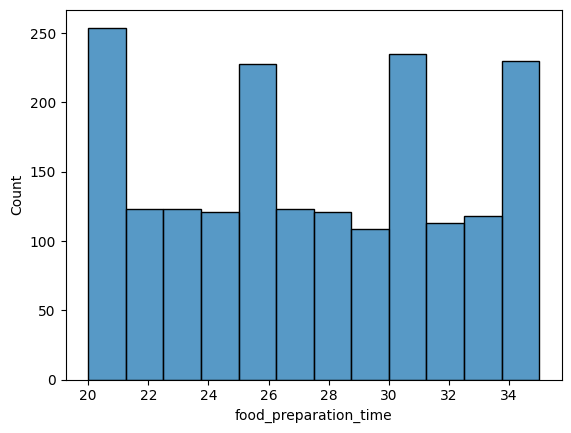

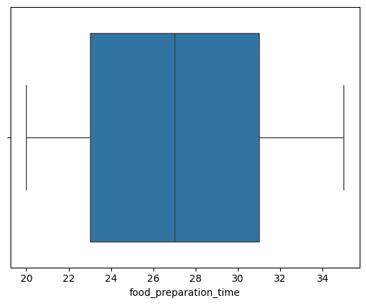

```python
sns.histplot(data=df,x='food_preparation_time')
plt.show()
sns.boxplot(data=df,x='food_preparation_time')
plt.show()
```

## Delivery Time

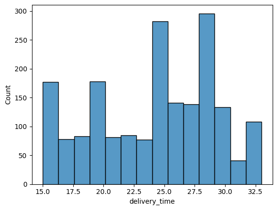

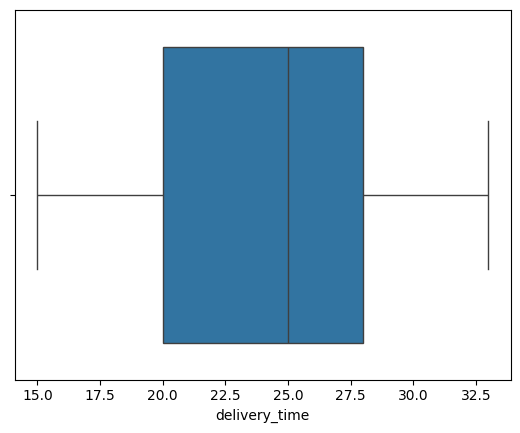

```python
sns.histplot(data=df,x='delivery_time')
plt.show()
sns.boxplot(data=df,x='delivery_time')
plt.show()
```

## **Quick Insights – 3**

1. A large proportion of orders fall between **10 and 20**, showing this is the most common spending range.
2. A small number of high-value orders (30+) exist, which may represent: bulk orders, premium restaurants, group orders.
3. Rating suggests there are highly satified customers.
4. Preparation & delivery time indicates fairly controlled/consistent cooking and delivery.